# Practical Statistics

This code was presented in Practical Statistics for Data Scientists by Bruce & Bruce. I have recreated it here, to practice my skills and create a virtual reference to use as I learn R.

# Exploratory Data Analysis

For the first section of exploratory analysis, we are going to use state populations and murder rates.

```
##             State Population Murder.Rate Abbreviation
## 1         Alabama    4779736         5.7           AL
## 2          Alaska     710231         5.6           AK
## 3         Arizona    6392017         4.7           AZ
## 4        Arkansas    2915918         5.6           AR
## 5      California   37253956         4.4           CA
## 6        Colorado    5029196         2.8           CO
## 7     Connecticut    3574097         2.4           CT
## 8        Delaware     897934         5.8           DE
## 9         Florida   18801310         5.8           FL
## 10        Georgia    9687653         5.7           GA
## 11         Hawaii    1360301         1.8           HI
## 12          Idaho    1567582         2.0           ID
## 13       Illinois   12830632         5.3           IL
## 14        Indiana    6483802         5.0           IN
```

[output cut: 36 more lines]

### Location Estimates of Population and Murder Rates

Below code finds the mean, trimmed mean, and median of state population. Trimmed mean’s are useful in controling for outliers and is a compromise between mean and median.

```r
mean(state[["Population"]])
```

```
## [1] 6162876
```

```r
## Trimming 10% off of both ends before calculating mean:
mean(state[["Population"]], trim=0.1)
```

```
## [1] 4783697
```

```r
median(state[["Population"]])
```

```
## [1] 4436370
```

```r
## Weighting the means by state population to get the overall murder rate of the country.
weighted.mean(state[["Murder.Rate"]],w=state[["Population"]])
```

```
## [1] 4.445834
```

### Variability Estimates of State Population

We can use R’s built in functions to find the standard deviation, interquartile range, and median absolution deviation from the mean:

```r
sd(state[["Population"]])
```

```
## [1] 6848235
```

```r
IQR(state[["Population"]])
```

```
## [1] 4847308
```

```r
mad(state[["Population"]])
```

```
## [1] 3849870
```

### Exploring Data Distribution

Quantile function can help to show the percentiles of the data:

```r
quantile(state[["Murder.Rate"]],p=c(.05, .25, .5, .75, .95))
```

```
##    5%   25%   50%   75%   95%
## 1.600 2.425 4.000 5.550 6.510
```

Boxplots help to show the distribution of data, based on percentiles:

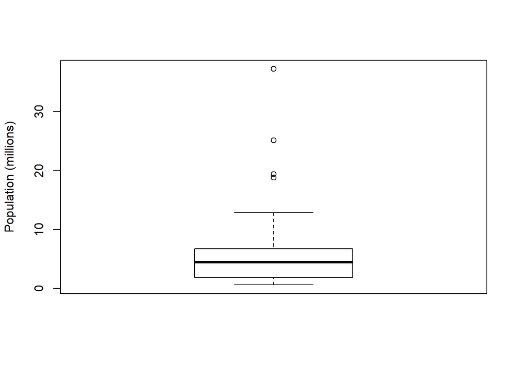

```r
boxplot(state[["Population"]]/1000000, ylab="Population (millions)")
```

Frequency Tables divide up the variable range into equally spaced segments, and show how many values fall into each segment.

Below shows the count of states that fall into specific segments of population (in millions).

```r
breaks <- seq(from=min(state[["Population"]]/1000000),to=max(state[["Population"]]/1000000),length=11)
pop_freq <- cut(state[["Population"]]/1000000, breaks=breaks,right=TRUE,include.lowest = TRUE)
table(pop_freq)
```

```
## pop_freq
## [0.564,4.23]   (4.23,7.9]   (7.9,11.6]  (11.6,15.2]  (15.2,18.9]
##           24           14            6            2            1
##  (18.9,22.6]  (22.6,26.2]  (26.2,29.9]  (29.9,33.6]  (33.6,37.3]
##            1            1            0            0            1
```

We can interpret this as 24 states have populations between 564,000 and 4,230,000. One state is significantly larger than others (California) and is the lone state in the uppermost segment.